# Statistical frameworks

PCB 6455 / BSC 4933: Biometry | Lecture 3

Dr. Brian Maitner

## Today’s agenda

1. Ways to do statistics
2. R code basics
3. The modeling process
4. Code: build a dataset, fit it, test it

Type and run on a code block: type it into your script and run it. Code without the label is there to watch.

## The story so far

**Lecture 1:** why we need statistics, and why we do it in R.

**Lecture 2:** the choices behind a model, and where its scatter comes from.

**Today:** the different ways to turn data into an answer, and our first real code.

# Ways to do statistics

## How many ways are there to do statistics?

**Three:** frequentist, likelihood, and Bayesian.

This course focuses mostly on **likelihood**.

## One dataset, three answers

Bolker’s example, from Duncan and Duncan (2000):

Seeds at **941 stations** in Kibale, Uganda, from two species: *Polyscias* (tiny seeds) and *Pseudospondias* (seeds of about 50 g).

Seeds were taken at **51** stations.

**Does being taken depend on species?**

## Three meanings of probability

|  | Probability is | The question it asks | The answer |
| --- | --- | --- | --- |
| **Frequentist** | a long-run frequency | assume nothing is going on: how surprising is what we saw? | a p-value |
| **Likelihood** | the probability of the data, given the parameters | which parameter values make what we saw most probable? | an estimate, with support |
| **Bayesian** | a degree of belief | start with a prior, update it with the data | a posterior distribution |

A frequentist asks how surprising the data are if nothing is going on; likelihood asks which values make the data most probable; a Bayesian asks what to believe after seeing the data.

## Likelihood and Bayes, drawn

Seeds taken at 51 of 941 stations. What is the chance a station loses its seeds?

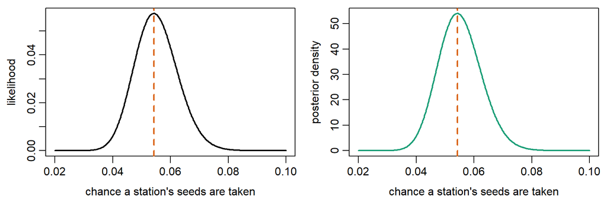

**Left:** how probable 51 of 941 is, for each possible chance. It peaks at 51/941 = 0.05. **Right:** the Bayesian posterior, from a flat prior: the same shape.

## Same data, same conclusion

| Framework | Method | Result |
| --- | --- | --- |
| **Frequentist** | Fisher’s exact test | p = 3.8 × 10⁻⁶ |
| **Likelihood** | maximum likelihood + likelihood ratio | estimate 3.62, limits 2.13 to 6.16 |
| **Bayesian** | flat prior | mode 3.48, credible interval 2.01 to 6.01 |

None of the intervals include 1.

The frameworks agree on the conclusion. They differ in what the numbers **mean**.

## The three frameworks, compared (1 of 2)

|  | Frequentist | Likelihood | Bayesian |
| --- | --- | --- | --- |
| **Probability is** | the long-run frequency of events | the probability of the data, given parameters | a degree of belief |
| **Parameters** | fixed but unknown | fixed but unknown | random variables with distributions |
| **Data** | random (due to sampling) | fixed: the thing whose probability we evaluate | fixed: they update beliefs about parameters |
| **Prior information** | not used | not used | required (informative or weak) |
| **Main output** | point estimates, confidence intervals, p-values | point estimates, likelihood-based confidence limits | posterior distributions, credible intervals, Bayes factors |

## The three frameworks, compared (2 of 2)

|  | Frequentist | Likelihood | Bayesian |
| --- | --- | --- | --- |
| **Interval** | 95% CI: in repeated samples, 95% of intervals contain the true value | support interval: values that make the data nearly as probable as the best estimate | 95% credible interval: given data and prior, a 95% chance the parameter is inside |
| **How** | hypothesis tests, maximum likelihood, resampling | maximize the likelihood; compare models by likelihood ratio test | Bayes’ theorem: prior × likelihood → posterior |
| **Computation** | often formulas, asymptotics, bootstraps | numerical optimization | often simulation (MCMC, variational inference) |
| **Common critique** | ignores prior knowledge; p-values easily misread | no probability statement about the parameter itself; relies on asymptotics in small samples | can be subjective (depends on the prior); computationally intensive |
| **Example question** | “If we repeated this study many times, how often would we see results like this?” | “Which parameter values make my data most probable?” | “Given the data, what is the probability the hypothesis is true?” |

# R code basics

## Let’s use it

1. Open RStudio, in the **project** you made last time
2. **File > New File > R Script**, and save it in the project
3. **Type along. Don’t paste**: typing helps you remember

Run a line, or a selection, with **Ctrl+Enter** (Cmd+Enter on a Mac), or the Run button.

## R as a calculator

```r
2 * 8
```

```
[1] 16
```

```r
sqrt(25)
```

```
[1] 5
```

What does the output look like? **What does `[1]` refer to?**

## Assignment

```r
x <- sqrt(36)
x
```

```
[1] 6
```

What does the first line do? **Why is nothing shown when you run `x <- sqrt(36)`?**

`<-` is read “gets”. The book uses `=` for assignment; `<-` is now standard practice.

## Getting help

```r
?sqrt
example(sqrt)
help.search("correlation")
```

What’s different about them? What’s similar?

These are a good place to start; Lecture 27 goes further.

# The modeling process

## What is the modeling process?

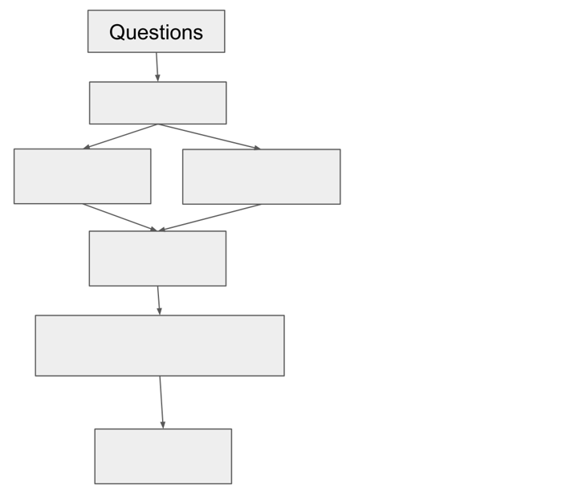

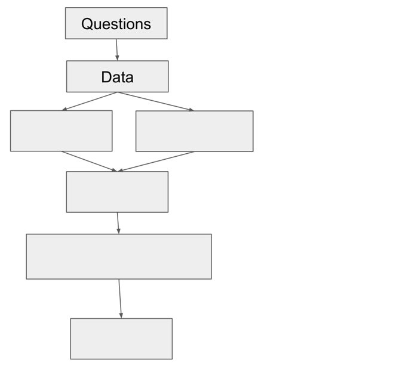

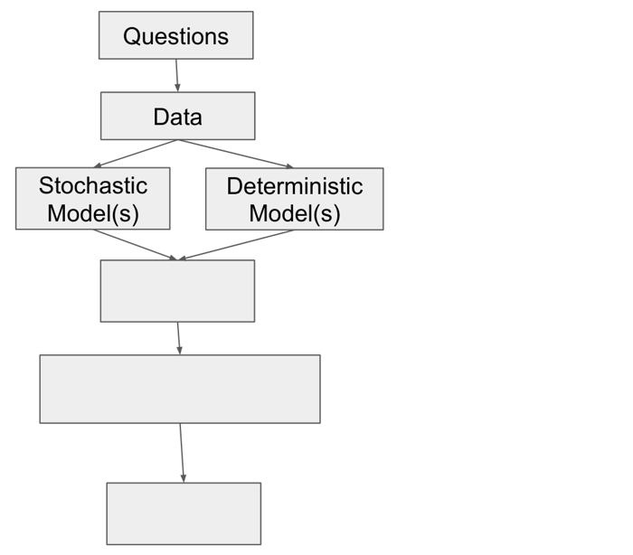

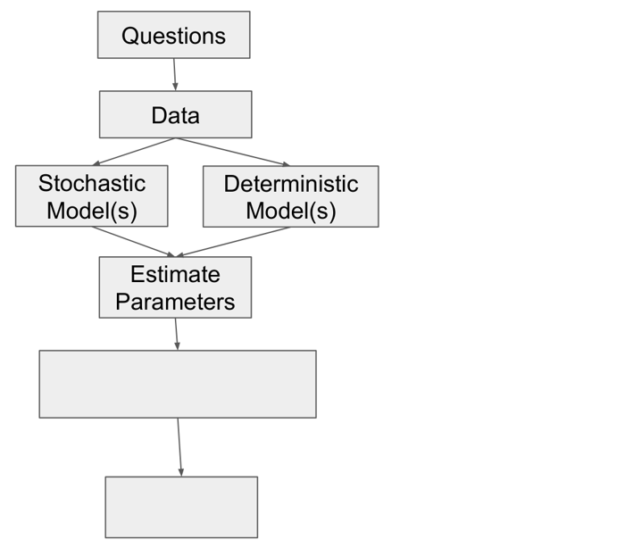

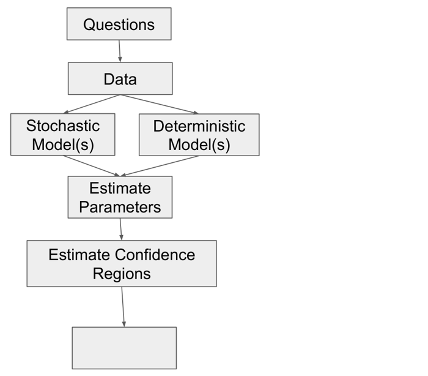

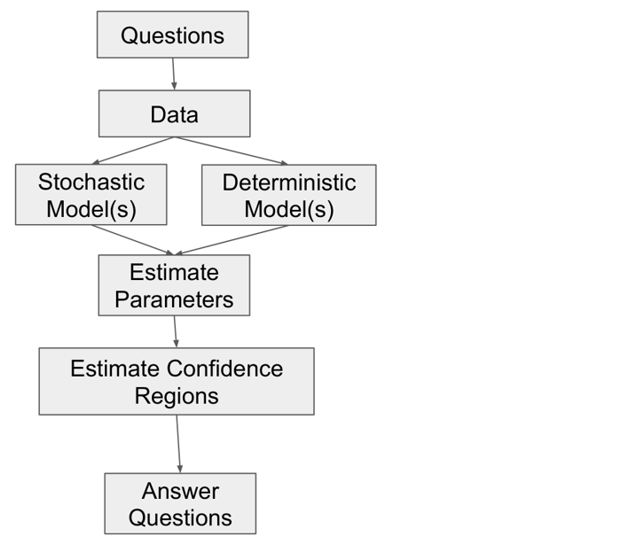

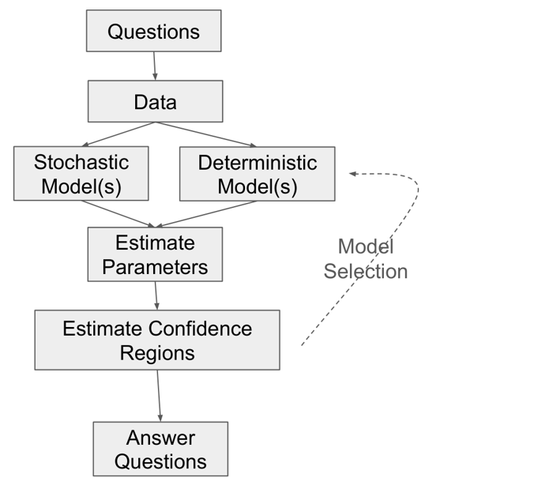

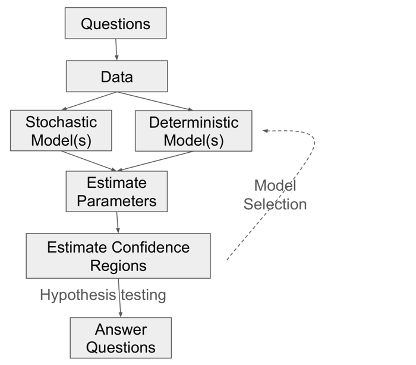

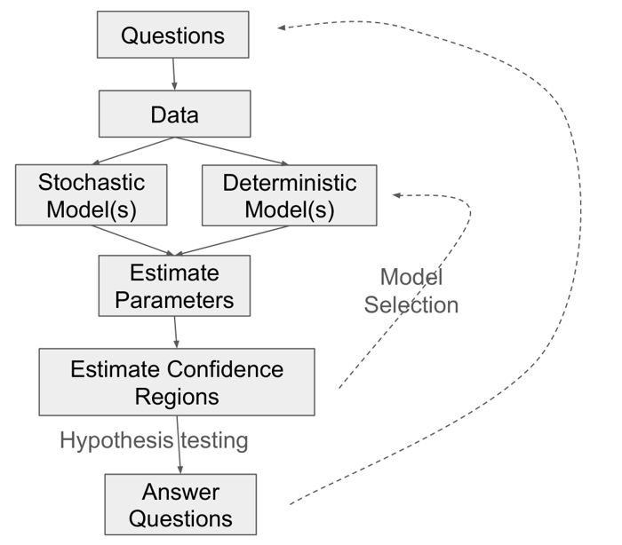

## Asking a good question

Consider two levels:

**General:** does disease select against cannibalism in tiger salamanders?

**Specific:** what is the difference in the probability of becoming a cannibal between populations A and B?

General is how you **talk** about the question. Specific is how you **test** it.

**Too vague:** “I want to explore the population genetics of cannibalism”, which is hard to test.  
**Too specific:** “What is the difference in the intercepts of these two linear regressions?”, which leads to uninteresting questions.

## Your turn: two levels

Take the question you thought about last time.

1. **Write it at the other level**: general if you had specific, specific if you had general
2. **Swap with a neighbor.** Can they tell which is which?

# Code: build, fit, test

## First we’ll play nature

We’ll **build a dataset where we know the true answer**:

- `mean = 2 * frogs`: the real signal
- `sd = 0.5`: the real noise

Then we’ll forget we know, analyze it, and see whether the analysis can **recover the truth**.

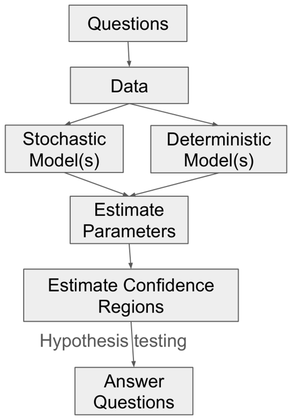

## The signal

```r
frogs <- c(1.1, 1.3, 1.7, 1.8, 1.9, 2.1,
           2.3, 2.4, 2.5, 2.8, 3.1, 3.3,
           3.6, 3.7, 3.9, 4.1, 4.5, 4.8,
           5.1, 5.3)
frogs
```

`frogs` is a **vector** of length 20: adult frog density in 20 populations. `c()` combines values into one.

## The noise

```r
set.seed(101)
tadpoles <- rnorm(n = 20,
                  mean = 2 * frogs,
                  sd = 0.5)
tadpoles
```

- `mean = 2 * frogs` is the **deterministic** model
- `sd = 0.5` is the **stochastic** model

**Check:** the first value is 2.04.

## Look at it

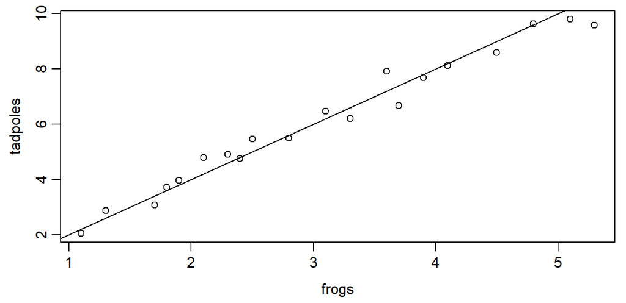

```r
plot(x = frogs, y = tadpoles)
abline(a = 0, b = 2)
```

The line is the truth. **Why don’t the points sit on it?**

## Turn the noise up

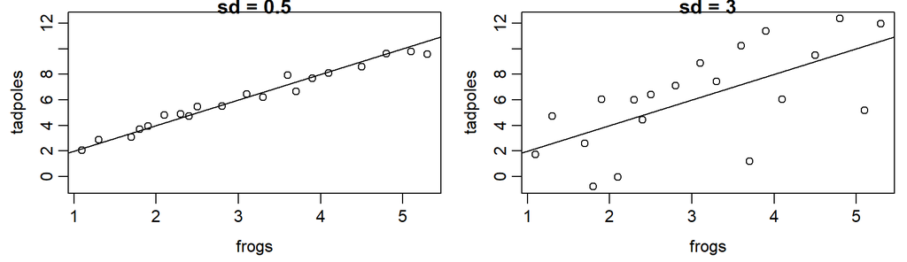

```r
tadpoles_noisy <- rnorm(n = 20, mean = 2 * frogs, sd = 3)
plot(x = frogs, y = tadpoles_noisy)
abline(a = 0, b = 2)
```

Same relationship. **Would you have spotted it this time?**

## Can we recover the truth?

```r
frog_lm <- lm(tadpoles ~ frogs)
frog_lm_noisy <- lm(tadpoles_noisy ~ frogs)

coef(frog_lm)
coef(frog_lm_noisy)
confint(frog_lm)
```

The real slope is 2. **Which one got closer?** (You just fit two linear models.)

**Check:** slopes of 1.84 and 2.01.

## Our interval missed

`confint(frog_lm)` gives 1.69 to 1.98. The true slope is 2: **not in there.**

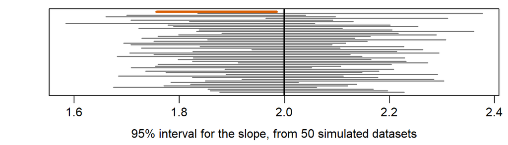

Ours was one of the 5% that miss, like the orange ones above.

A 95% interval comes from a method that is right 95% of the time; any one interval can miss.

## One draw proves little

```r
slopes_clean <- replicate(1000,
  coef(lm(rnorm(20, 2 * frogs, sd = 0.5) ~ frogs))[2])
slopes_noisy <- replicate(1000,
  coef(lm(rnorm(20, 2 * frogs, sd = 3) ~ frogs))[2])

mean(slopes_clean)
mean(slopes_noisy)
sd(slopes_clean)
sd(slopes_noisy)
```

**What did adding noise do?**

**Check:** both means near 2; spreads about 0.09 and 0.54.

## One draw proves little

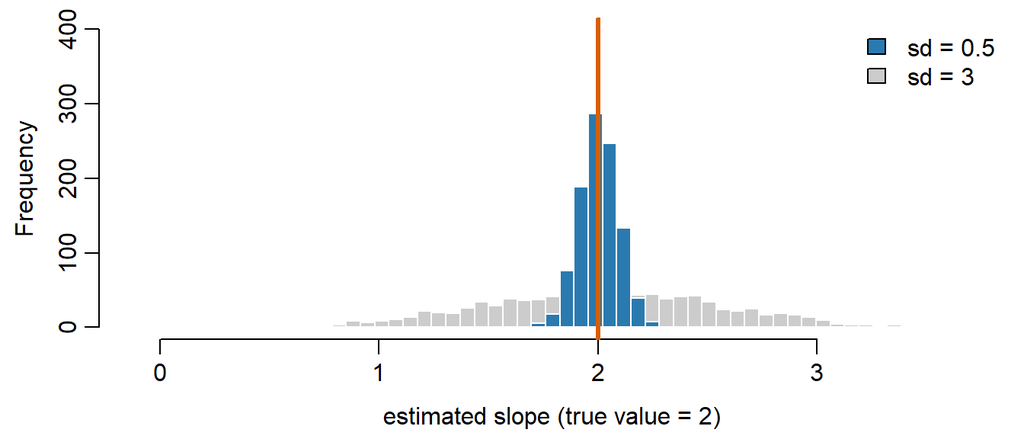

Both are **centered on the truth**: noise does not bias the slope. It makes any **one** estimate less reliable.

## Summarize and test

```r
mean(tadpoles)
summary(tadpoles)
cor(frogs, tadpoles)
cor.test(frogs, tadpoles)
```

**Is that p-value impressive?**

**Check:** correlation 0.987; p is tiny.

## Run it again

```r
set.seed(202)
tadpoles2 <- rnorm(n = 20, mean = 2 * frogs, sd = 0.5)
cor(frogs, tadpoles2)
```

**How did this differ? Why?**

Different data, same truth: the stochastic part of the model at work.

**Check:** 0.990, against 0.987 before.

## What we just did

| Flowchart box | Here | Code |
| --- | --- | --- |
| Data | 20 populations | `c()`, `rnorm()` |
| Deterministic model | the line `lm()` fits | `lm()` |
| Stochastic model | the normal errors it assumes | `lm()` |
| Estimate parameters | the slope | `coef()` |
| Confidence regions | its 95% interval | `confint()` |
| Hypothesis testing | is there a correlation? | `cor.test()` |

**`lm()` never saw how we made the data.**

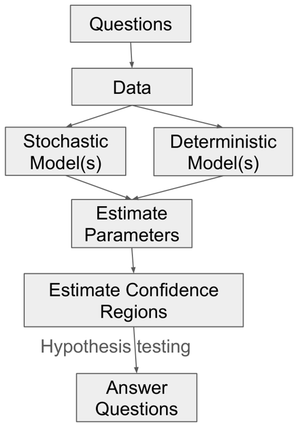

## Before next class

Read Bolker **2.1 to 2.3**

Think about the kinds of data you might want to work with this semester

Next class: discuss 2.1 to 2.3, and start loading data into R

May be a quiz.